# Soc723 - TE Chapter 13

Turgut Keskintürk

2023-03-02

Hello there! Let’s start our exercises for Huntington-Klein’s *The Effect*, Chapter 13.

# Conceptual Questions

## Q1

The *error* for Observation A is 1 in the simulated data, while the *residual* from the model is 0.9.

## Q2

Alright, looking at the DAG shows us that the adjustment set consists of ${A, B}$. Thus, the equation is $Y = \beta_0 + \beta_1A + \beta_2B$.

## Q3

The coefficient $\hat{B}_1$ means that, for each unit increase in $X$, we see an increase of 3 units in $Y$. The coefficient is significant (sigh), with t-value is above 1.96 ($t = 2.31$), meaning that the coefficient is precisely different from 0 at $\alpha = 0.05$.

## Q4

Here are the answers for the questions: (a) $76.2$ hours worked, (b) the standard error is $19.7$, (c) the model 3 intercept, which is $306.6$, (d) the *N* is $3,382$ in all models, and (e) yes, it is significant ($t = -13$).

## Q5

Here are the answers for the questions: (a) $110.230 - 3.162*YearsEducation$, (b) this is $110.230 - 3.162*16 = 59.64$, (c) it gets less positive, and (d) the diminishing return is scientifically reasonable, we might overfit otherwise!

## Q6

Here are the answers for the questions: (a) the coefficient on $Homeowner$ is the conditional mean difference for home-owners and non-home-owners, which is $50.2$ hours, (b) this is $150.5$ hours, and (c) no – we might change the ordering.

## Q7

Here are the answers for the questions:

1. A positive increase of $110.1$,
2. Assuming that earnings means hours, an increase of $683$ hours, which is significant at $\alpha = 0.05$,
3. The coefficient $Homeowner x Education$ basically measures whether the effect of $Education$ on $Hours$ is different across $Homeowner$ status (or vice versa in terms of position). It says that the return is lower for homeowners,
4. Since the outcome is logged, one unit change in $Education$ means $0.067 * 100 = 6.7 \%$ change in $Hours$,
5. 10% increase in education is $832.35/10 = 83.2$ change in hours worked,
6. There are probably cases where the individuals do not work at all, with Annual Hours Worked equal to 0.

## Q8

The best definition is (a), suggesting that there is information across groups, with some form of aggregating unit (e.g., time).

## Q9

The heteroskedasticity is the change in variation across the values of $X$, so (b) applies. It is also reasonable to assume that, if there is strong heteroskedasticity, the explained variance is likely low; hence, (d) also applies.

## Q10

Well, this is simply sample weights, where certain observations are weighted according to a prespecified distribution.

## Q11

When the measurement error is non-classical, the error term is somehow related to our true value. Thus, the answer is (a), where there is systematic error in retrieving the true values (some people are *systematically* underreporting $X$).

# Coding Questions

## Q1

Let’s load the data.

```r
d <- read.csv("https://vincentarelbundock.github.io/Rdatasets/csv/DAAG/dengue.csv")
```

## Q2

A regression of whether dengue is observed on average humidity:

```r
m1 <- lm(NoYes ~ humid, data = d)
modelsummary(m1)
```

|  | (1) |
| --- | --- |
| (Intercept) | −0.416 |
|  | (0.018) |
| humid | 0.050 |
|  | (0.001) |
| Num.Obs. | 1998 |
| R2 | 0.548 |
| R2 Adj. | 0.548 |
| AIC | 1258.9 |
| BIC | 1275.7 |
| Log.Lik. | −626.466 |
| F | 2424.483 |
| RMSE | 0.33 |

## Q3

The estimations show that if average humidity is 0, the probability of observing dengue is -42% (hell yeah). For each unit increase in humidity, the model expects 5% increase in the probability of observing dengue, which is *significant* at $\alpha = 0.05$.

## Q4

Here is the summary statistics for the $humid$ variable:

```r
d |> select(humid) |> summary() |> t()
```

```
##
##     humid Min.   : 0.6714   1st Qu.:10.0088   Median :16.1433
##
##     humid Mean   :16.7013   3rd Qu.:23.6184   Max.   :30.2665   NA's   :2
```

As we can see, the minimum value of humidity is $0.67$, which is helpful in the sense that the intercept is the value where humidity is $0$, which is out-of-scope of our predictor. Thus, it is advisable not to interpret this weird intercept at all!

## Q5

OK, we are going to add the temperature to the model:

```r
m2 <- lm(NoYes ~ humid + temp, data = d)
modelsummary(m2)
```

|  | (1) |
| --- | --- |
| (Intercept) | −0.407 |
|  | (0.019) |
| humid | 0.053 |
|  | (0.002) |
| temp | −0.003 |
|  | (0.002) |
| Num.Obs. | 1998 |
| R2 | 0.549 |
| R2 Adj. | 0.549 |
| AIC | 1257.5 |
| BIC | 1279.9 |
| Log.Lik. | −624.758 |
| F | 1215.415 |
| RMSE | 0.33 |

## Q6

Let’s fit the logistic regression and print the average marginal effects of $humid$ and $temp$:

```r
m3 <- glm(NoYes ~ humid + temp, data = d, family = "binomial")
m3 |> margins(variables = c("humid", "temp")) |> summary()
```

```
##  factor    AME     SE       z      p  lower  upper
##   humid 0.0317 0.0015 20.4727 0.0000 0.0287 0.0348
##    temp 0.0042 0.0020  2.0612 0.0393 0.0002 0.0081
```

## Q7

This time we are interested in the relationship between humidity and temperature. Let’s do it!

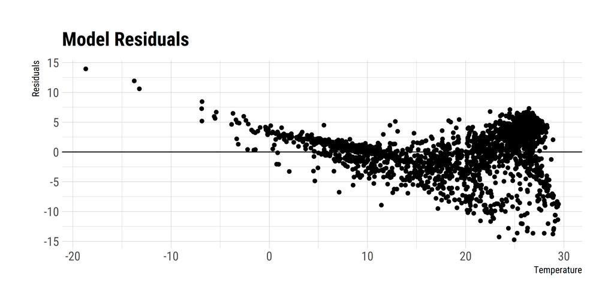

```r
# processing
d <- d |> filter(is.na(humid) == FALSE)

# estimate
m4 <- lm(humid ~ temp, data = d)

# residuals
d <- d |> mutate(res = resid(m4))

# plot the variance
d |>
  ggplot(aes(x = temp, y = res)) +
  geom_point() +
  geom_hline(yintercept = 0) +
  labs(title = "Model Residuals",
       x = "Temperature", y = "Residuals")
```

Horrendous! The `modelsummary` package allows me to estimate the regression with robust standard errors, so here it is:

```r
modelsummary(m4, title = "Regular Model")
```

Regular Model

|  | (1) |
| --- | --- |
| (Intercept) | 2.362 |
|  | (0.211) |
| temp | 0.779 |
|  | (0.011) |
| Num.Obs. | 1998 |
| R2 | 0.733 |
| R2 Adj. | 0.733 |
| AIC | 10998.5 |
| BIC | 11015.3 |
| Log.Lik. | −5496.246 |
| F | 5483.194 |
| RMSE | 3.79 |

```r
modelsummary(m4, vcov = "HC1", title = "Robust Standard Errors")
```

Robust Standard Errors

|  | (1) |
| --- | --- |
| (Intercept) | 2.362 |
|  | (0.196) |
| temp | 0.779 |
|  | (0.012) |
| Num.Obs. | 1998 |
| R2 | 0.733 |
| R2 Adj. | 0.733 |
| AIC | 10998.5 |
| BIC | 11015.3 |
| Log.Lik. | −5496.246 |
| F | 4563.858 |
| RMSE | 3.79 |
| Std.Errors | HC1 |

As we can see, the standard errors are slightly inflated, suggesting that there is indeed some heteroskedasticity.

## Q8

OK, the same model, but this time humidity with logarithmic transformation:

```r
m5 <- lm(log(humid) ~ temp, data = d)
modelsummary(m5, vcov = "HC1", title = "Robust Standard Errors")
```

Robust Standard Errors

[output not shown]

One unit change in temperature leads to 5.6% change in humidity.

## Q9

If we look at the plot below, we see that there is a marginal return to increased temperature. Once we log the humidity, we capture this marginal relationship; hence, linear in log is increased (or decreased) return to our predictor.

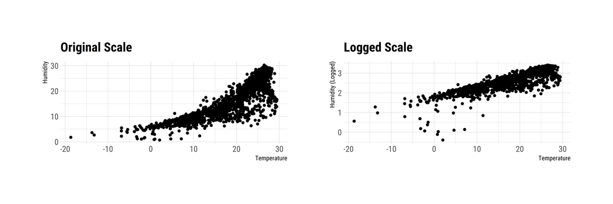

```r
p1 <- d |>
  ggplot(aes(x = temp, y = humid)) +
  geom_point() +
  labs(title = "Original Scale", x = "Temperature", y = "Humidity")

p2 <- d |>
  ggplot(aes(x = temp, y = log(humid))) +
  geom_point() +
  labs(title = "Logged Scale", x = "Temperature", y = "Humidity (Logged)")

p1 + p2
```